# Machine Learning in Public Health

Lecture 2: Linear Regression

Dr. Yang Feng

# Happy New Year

[figure not shown]

# Today’s agenda

- Simple Linear Regression
- Multiple Linear Regression
- Qualitative Predictors
- $K$-Nearest Neighbors for Regression

# Linear regression with a single variable

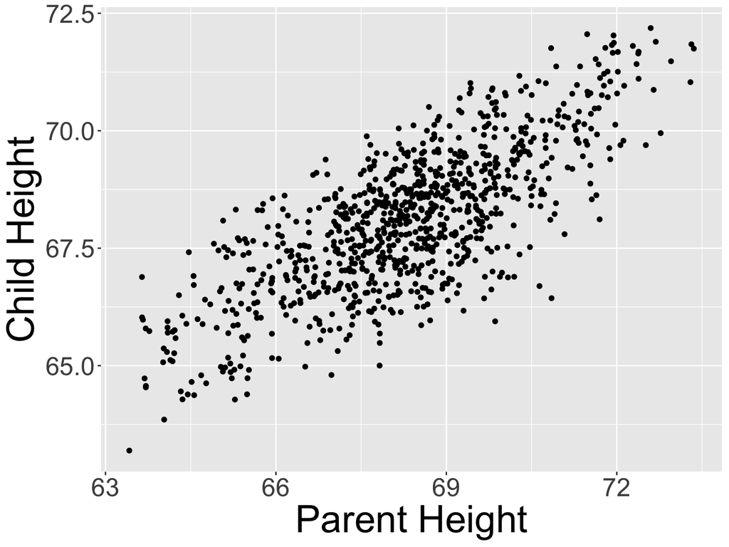

- Goal: predict child's height $Y$ from parent's height $X$
  - Call $Y$ the **reponse**, also called **dependent** variable
  - Call $X$ the **predictor**, also called **independent** variable

# Predict child's heights using parent's heights

- A naive idea:
  $$\widehat{Y} = X$$

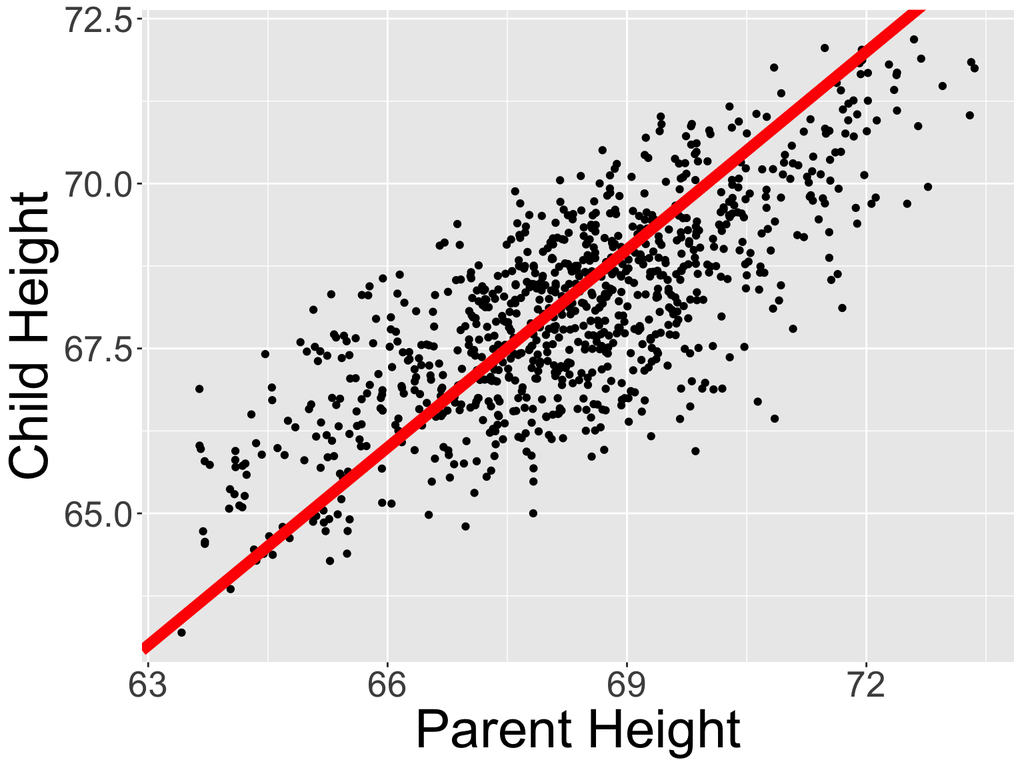

# Predit child's heights using parent's heights

- Probably a better idea: $\widehat{Y} = \underbrace{\widehat{\beta}_0}_{\rm intercept} + \underbrace{\widehat{\beta}_1}_{\rm slope} X$
- The **best** fit line of this form. (what does “best” mean?)

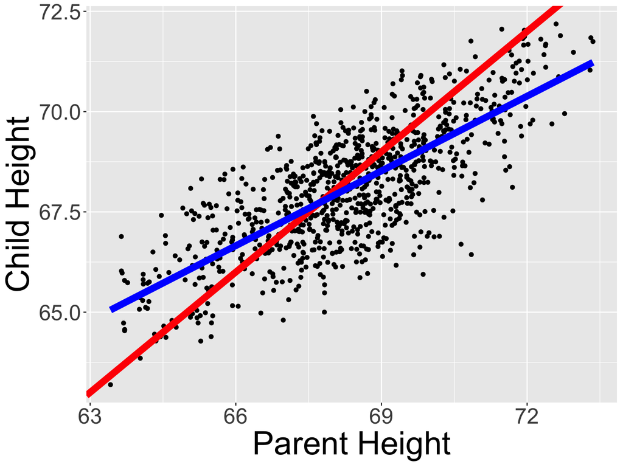

# Simple Linear Regression Model

George Box:

All models are wrong; some models are useful…

- Predict a quantitative response $Y$ using a single predictor $X$.
- The simplest of all is a (simple) *linear* regression model; that is, the *response* or *target* $Y$ satisfies
  $$Y = \beta_0 + \beta_1 X + \epsilon$$
- $\beta_0$ is the *intercept* term
- $\beta_1$ is the *slope*
- $\beta_0$ and $\beta_1$ are *coefficients* or *parameters* of the linear model. They are usually **unknown**.
- $\epsilon$ is a noise term, which is usually assumed independent of $x$ and mean zero. It is often assumed to be normally distributed in theoretical analysis.
- Often, we assume the variance of $\varepsilon$ is $\sigma^2$, which is another **unknown** parameter of the simple linear regression model.

# Estimating the Coefficients (1)

- **Data**: Suppose the training data contains $(x_1, y_1), (x_2, y_2), \cdots, (x_n, y_n)$, where $x_i$ is the height of parent $i$ and $y_i$ is height of child $i$. $n$ is the **sample size**.

- |  | child | parent |
  | --- | --- | --- |
  | 1 | 66.43592 | 70.85107 |
  | 2 | 65.94336 | 69.85889 |
  | 3 | 64.27886 | 65.27814 |
  | 4 | 63.85191 | 64.03263 |
  | 5 | 63.19229 | 63.41899 |
  | 6 | 65.00112 | 67.82480 |

- **Predictions**: For an estimate $\hat\beta_0$ and $\hat\beta_1$, the prediction is $\hat{y} = \hat\beta_0 + \hat\beta_1 x$ of the height of child if a parent has height $x$.
- **Loss function**: How do we measure the quality of the fit. First, define the *residual* $e_i = y_i -\hat{y}_i$.
  $$Loss(y, \hat{y}) = (y - \hat{y})^2$$
- Why does this loss function make sense? It is the only loss function that makes sense?

# Estimating the Coefficients (2)

- **Training Loss**: we can just sum up the loss for all $n$ observations.
  $$\begin{align}
  L(\hat\beta_0, \hat\beta_1) &= \sum_{i=1}^n Loss(y_i, \hat{y_i})\\
  &= \sum_{i=1}^n (y_i - \hat{y_i})^2 \\
  &= \sum_{i=1}^n (y_i - \hat\beta_0 - \hat\beta_1 x_i)^2
  \end{align}$$
- Find $\hat\beta_0$ and $\hat\beta_1$ that **minimizes** the overall training loss.
  $$\mathop{\rm minimize}_{\beta_0, \beta_1} L(\beta_0, \beta_1)$$
- The minimizer is called the **least squares estimate**, denoted as $\hat \beta_0$ and $\hat \beta_1$.

# Residual Sum of Squares and Total Sum of Squares

- Residual Sum of Squares
  $$\begin{align}
  RSS &= \sum_{i=1}^n e_i^2\\
  &= \sum_{i=1}^n(y_i - \hat\beta_0 - \hat\beta_1 x_i)^2\\
  &= (y_1 - \hat\beta_0 - \hat \beta_1 x_1)^2 + \cdots + (y_n - \hat\beta_0 - \hat \beta_1 x_n)^2
  \end{align}$$
- Here, $e_i$ is the residual for the $i$-th observation.
- Total Sum of Squares: corresponding to $\hat\beta_0 = \bar y$ and $\hat\beta_1 = 0$.
  $$\begin{align}
  TSS &= \sum_{i=1}^n(y_i - \bar y)^2
  \end{align}$$

# $R^2$: coefficient of determination

$$\begin{align}
R^2 &= 1 - \frac{RSS}{TSS}
\end{align}$$

- $R^2\in[0,1]$ is the percent of the variation in the response explained by the regression model
- $R^2$ is a common measure for how good a linear fit is.
- Q: is a bigger $R^2$ always better?

# Least Square Estimates

- Exact formula
  $$\hat \beta_1 = \frac{\sum_{i=1}^n (x_i-\bar x)(y_i - \bar y)}{\sum_{i=1}^n (x_i - \bar x)^2} \text{ and } \hat\beta_0 = \bar y - \hat\beta_1 \bar x$$
  - Remark: every least squares regression line passes $(\bar x, \bar y)$.
- Optimization techniques.
  $$\begin{align}
  \frac{\partial L(\beta_0, \beta_1)}{\partial\beta_0} &=0\\
  \frac{\partial L(\beta_0, \beta_1)}{\partial\beta_1} &=0
  \end{align}$$

# Multiple Regression: more than one predictors

In addition to scalar input $x \in \mathbb{R}$, we can consider vector input $x \in \mathbb{R}^p$

- $p$ is feature dimension of input (sometimes use $d$ for *dimension*)
- Inputs of form
  $$x = \left[\begin{matrix} x_1 \\ x_2 \\ \vdots \\ x_p \end{matrix} \right]$$
- Call $x$ the *covariates*, *independent variables*, *explanatory variables*, *features*, *attributes* or *predictor variables*
  - Note that variables are usually NOT independent of one another

# Example: Boston housing data

- Output (response, target, dependent) variable is medv, the median home price in neighborhoods of Suburbs of Boston
- Input variables include (but not limited to)
  - crim: per capita crime rate by town
  - rm: average number of rooms per dwelling
  - zn: proportion of large lots (zoned for > $25,000$ feet)
  - chas: whether a home is near the Charles river ($x \in \{0, 1\}$)
  - ptratio: pupil-teacher ratio by town
- Let’s do a little data exploration

  |  | crim | rm | zn | chas | ptratio | medv |
  | --- | --- | --- | --- | --- | --- | --- |
  | 1 | 0.00632 | 6.575 | 18 | 0 | 15.3 | 24.0 |
  | 2 | 0.02731 | 6.421 | 0 | 0 | 17.8 | 21.6 |
  | 3 | 0.02729 | 7.185 | 0 | 0 | 17.8 | 34.7 |
  | 4 | 0.03237 | 6.998 | 0 | 0 | 18.7 | 33.4 |
  | 5 | 0.06905 | 7.147 | 0 | 0 | 18.7 | 36.2 |
  | 6 | 0.02985 | 6.430 | 0 | 0 | 18.7 | 28.7 |

# Boston housing: Number of Bedrooms

Idea: let us run a regression on each of these, and see which is best, first, the number of bedrooms `rm`.

```r
fit_rm <- lm(medv ~ rm, data = boston)
fit_rm
```

```
##
## Call:
## lm(formula = medv ~ rm, data = boston)
##
## Coefficients:
## (Intercept)           rm
##     -34.671        9.102
```

- To run a regression on a data frame, we tell R to use a formula with the column(s) we care about and the data frame we want.

# Measuring the fit

Compute its fitted values $\hat y_i$ and residuals

```r
df_rm <- data.frame(true_response = boston$medv,
           fitted_response = fit_rm$fitted.values,
           residual = fit_rm$residuals)
head(df_rm)
```

|  | true_response | fitted_response | residual |
| --- | --- | --- | --- |
| 1 | 24.0 | 25.17575 | -1.175746 |
| 2 | 21.6 | 23.77402 | -2.174021 |
| 3 | 34.7 | 30.72803 | 3.971968 |
| 4 | 33.4 | 29.02594 | 4.374062 |
| 5 | 36.2 | 30.38215 | 5.817848 |
| 6 | 28.7 | 23.85594 | 4.844060 |

Its $R^2=$ 0.4835255

# Visualization

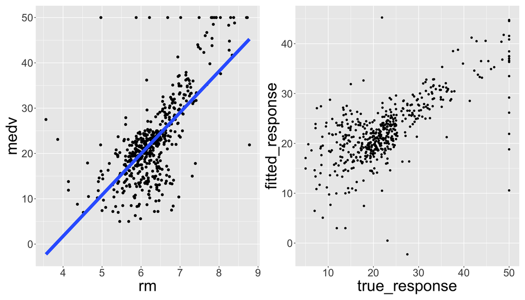

# Boston housing: Charles River

```r
fit_chas <- lm(medv ~ chas, data = boston)
fit_chas
```

```
##
## Call:
## lm(formula = medv ~ chas, data = boston)
##
## Coefficients:
## (Intercept)         chas
##      22.094        6.346
```

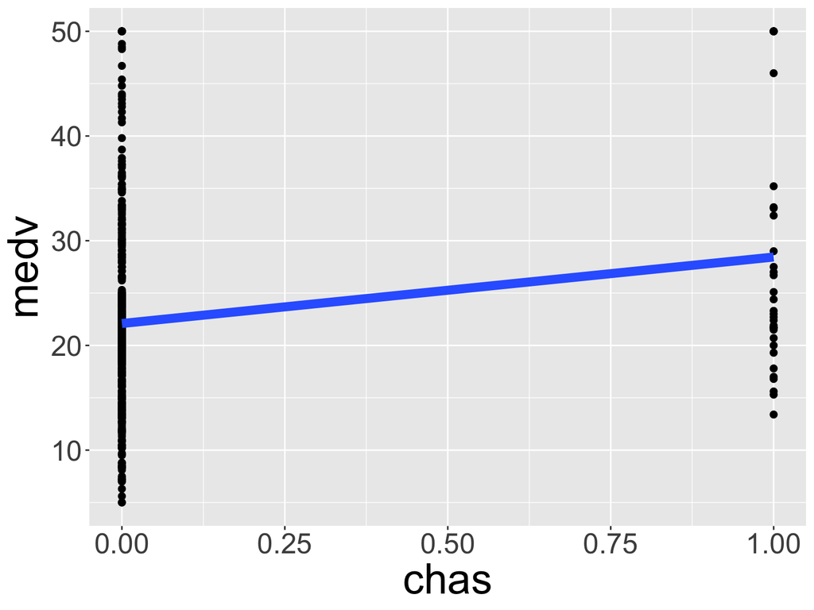

Its $R^2=$ 0.0307161

# Boston housing: Student to teacher ratio

```r
fit_ptratio <- lm(medv ~ ptratio, data = boston)
fit_ptratio
```

```
##
## Call:
## lm(formula = medv ~ ptratio, data = boston)
##
## Coefficients:
## (Intercept)      ptratio
##      62.345       -2.157
```

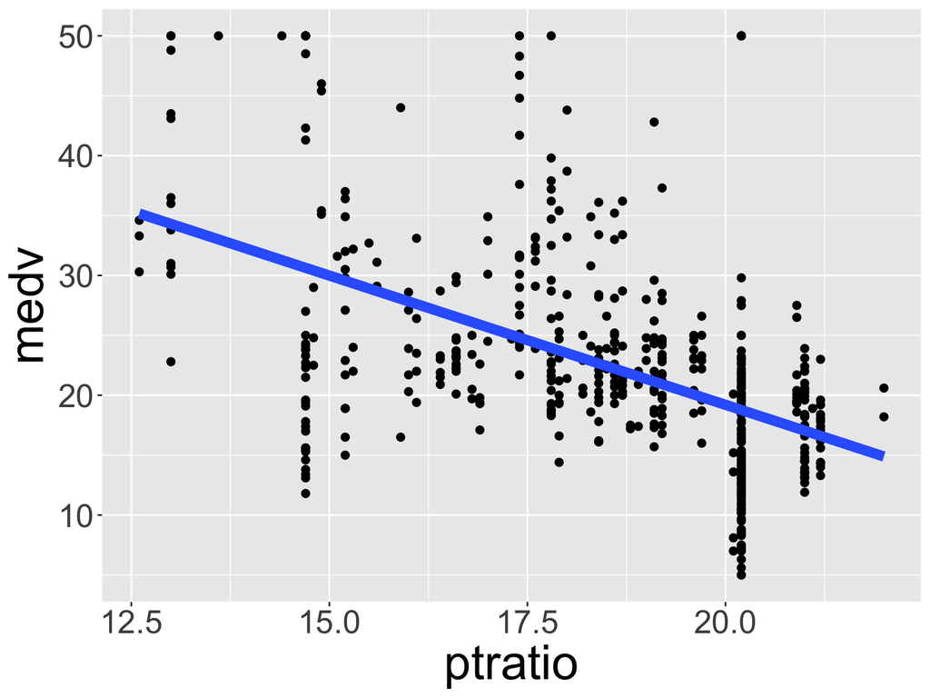

Its $R^2=$ 0.2578473

# When we use more than one input variables

- Make predictions
  $$\hat{y} = \hat\beta_0 + \sum_{j = 1}^p \hat\beta_j x_j$$
- Model the data as
  $$\begin{aligned}
  y & =\beta_0+\sum_{j = 1}^p \beta_j x_j + \varepsilon
  \end{aligned}$$
  where $\varepsilon$ is the random noise.

# Fitting a multiple regression

- Making predictions using
  $$\hat{y} = \hat\beta_0 + \sum_{j = 1}^p \hat\beta_j x_j$$
- Fit as in single variable case. Solve (least squares criterion)
  $$\mathop{\rm minimize}_{\beta_0 \in \mathbb{R}, \color{blue}{\beta \in \mathbb{R}^p}}
  \sum_{i = 1}^n (y_i - \beta_0 - \beta^T x_i)^2$$
- Since each observation has $p$ values, $x_i = (x_{i1}, \cdots, x_{ip})^T$, where $i = 1, \cdots, n$. In matrix notation, let $y = (y_1\cdots, y_n)^T$ and
  $$X = \begin{bmatrix}
  1 & x_{11} & x_{12} & x_{13} & \dots & x_{1p} \\
  1 & x_{21} & x_{22} & x_{23} & \dots & x_{2p} \\
  \vdots & \vdots & \vdots & \vdots & \ddots & \vdots \\
  1 & x_{n1} & x_{n2} & x_{n3} & \dots & x_{np}
  \end{bmatrix}$$
  where $x_{ij}$ is the $i$th observation of the $j$th variable.
- LS Solution
  $$\hat{\bf \beta} = (X^TX)^{-1}Xy.$$

# Boston housing: number of bedrooms and student to teacher ratio

```r
fit_rm_ptratio <- lm(medv ~ rm + ptratio, data = boston)
fit_rm_ptratio
```

```
##
## Call:
## lm(formula = medv ~ rm + ptratio, data = boston)
##
## Coefficients:
## (Intercept)           rm      ptratio
##      -2.561        7.714       -1.267
```

```r
summary(fit_rm_ptratio)$r.squared
```

```
## [1] 0.5612535
```

# Housing data: regression on everything

```r
fit_all <- lm(formula = medv ~ ., data = boston)
```

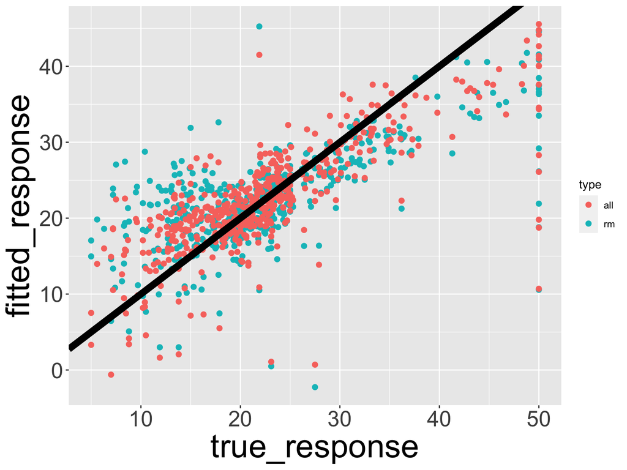

# Summary of `lm`

```r
summary(fit_rm_ptratio)
```

```
##
## Call:
## lm(formula = medv ~ rm + ptratio, data = boston)
##
## Residuals:
##     Min      1Q  Median      3Q     Max
## -17.672  -2.821   0.102   2.770  39.819
##
## Coefficients:
##             Estimate Std. Error t value Pr(>|t|)
## (Intercept)  -2.5612     4.1889  -0.611    0.541
## rm            7.7141     0.4136  18.650   <2e-16 ***
## ptratio      -1.2672     0.1342  -9.440   <2e-16 ***
## ---
## Signif. codes:  0 '***' 0.001 '**' 0.01 '*' 0.05 '.' 0.1 ' ' 1
##
## Residual standard error: 6.104 on 503 degrees of freedom
## Multiple R-squared:  0.5613, Adjusted R-squared:  0.5595
## F-statistic: 321.7 on 2 and 503 DF,  p-value: < 2.2e-16
```

# Is there a relationship between the reponse and all predictors?

- $H_0: \beta_1=\cdots=\beta_p=0$
- $H_a$: at least one of $\beta_j$ is non-zero
- Did we miss $\beta_0$?
- This hypothesis test is performed by computing the F-statistic,
  $$F = \frac{(TSS-RSS)/p}{RSS/(n-p-1)}$$
- The larger the F-statistic, the strong evidence against null hypothesis

# `ANOVA`

```r
anova(fit_rm_ptratio)
```

|  | Df | Sum Sq | Mean Sq | F value | Pr(>F) |
| --- | --- | --- | --- | --- | --- |
| rm | 1 | 20654.416 | 20654.4162 | 554.3367 | 3.508210e-83 |
| ptratio | 1 | 3320.252 | 3320.2525 | 89.1111 | 1.388009e-19 |
| Residuals | 503 | 18741.627 | 37.2597 | NA | NA |

- The **degrees of freedom** (df) for RSS is $n - p - 1 = 503$.
- The **degrees of freedom** (df) for TSS is $1 + 1 + 503 = 505 = n - 1$.
- What’s the sample size of this dataset?

# ANOVA: reduce model vs. full model

|  | Res.Df | RSS | Df | Sum of Sq | F | Pr(>F) |
| --- | --- | --- | --- | --- | --- | --- |
| 1 | 505 | 42716.30 | NA | NA | NA | NA |
| 2 | 503 | 18741.63 | 2 | 23974.67 | 321.7239 | 1.039313e-90 |

- Reduced model: `medv ~ 1` (no variable)
- Full model: `medv ~ rm + ptratio`

# Confidence Intervals

```r
confint(fit_rm_ptratio, level = 0.95) # 95% CI for the coefficients
```

```
##                  2.5 %    97.5 %
## (Intercept) -10.791000  5.668670
## rm            6.901448  8.526692
## ptratio      -1.530892 -1.003431
```

# Prediction using the linear regression model

```r
predict(fit_rm_ptratio, newdata = data.frame(rm=1, ptratio=2))
```

```
##        1
## 2.618583
```

```r
predict(fit_rm_ptratio, newdata = data.frame(rm=1, ptratio=2),
        level = 0.95, interval = "confidence")
```

```
##        fit       lwr      upr
## 1 2.618583 -4.509618 9.746783
```

```r
predict(fit_rm_ptratio, newdata = data.frame(rm=1, ptratio=2),
        level = 0.95, interval = "prediction")
```

```
##        fit       lwr      upr
## 1 2.618583 -11.33255 16.56972
```

# Train and testing in the linear regression model

We can split the data into training and testing.

```r
boston_tr <- boston[1:400, ]
boston_te <- boston[-(1:400), ]
```

1. Fit the model on the training data.

   ```r
   fit_rm <- lm(medv ~ rm, data = boston_tr)
   ```

2. Compute the fitted value on the training data and compute the training error.

   ```r
   pred_rm_train <- predict(fit_rm, newdata = boston_tr)
   train_error <- sum((pred_rm_train - boston_tr$medv)^2)
   train_error
   ```

   ```
   ## [1] 14521.32
   ```

3. Compute the predicted value on the test data and compute the test error.

   ```r
   pred_rm_test <- predict(fit_rm, newdata = boston_te)
   test_error <- sum((pred_rm_test - boston_te$medv)^2)
   test_error
   ```

   ```
   ## [1] 8440.338
   ```

# Qualitative Predictors

- Sometimes, **qualitative variables** (also called categorical variables) can be useful in making predictions.
- We usually code qualitative variables by **dummy variables** (variables taking values $0$ and $1$).

  |  | medv | rm | rm_cate |
  | --- | --- | --- | --- |
  | 1 | 24.0 | 6.575 | Big |
  | 2 | 21.6 | 6.421 | Medium |
  | 3 | 34.7 | 7.185 | Big |
  | 4 | 33.4 | 6.998 | Big |
  | 5 | 36.2 | 7.147 | Big |
  | 6 | 28.7 | 6.430 | Medium |

- Suppose you have a qualitative variable `rm_cate` with three : Small, Medium, Big. We need to code it with **two** dummy variables.
- Can we code the levels with one variable with values $1$, $2$ and $3$?
- Always recommended before applying any machine learning algorithms.
- R will automatically do the convertion for us in `lm()`

  ```
  ##
  ## Call:
  ## lm(formula = medv ~ rm_cate, data = boston)
  ##
  ## Residuals:
  ##     Min      1Q  Median      3Q     Max
  ## -22.417  -4.379   0.466   3.267  32.521
  ##
  ## Coefficients:
  ##               Estimate Std. Error t value Pr(>|t|)
  ## (Intercept)    17.4793     0.5766  30.315  < 2e-16 ***
  ## rm_cateMedium   2.7088     0.8166   3.317 0.000976 ***
  ## rm_cateBig     12.4379     0.8154  15.253  < 2e-16 ***
  ## ---
  ## Signif. codes:  0 '***' 0.001 '**' 0.01 '*' 0.05 '.' 0.1 ' ' 1
  ##
  ## Residual standard error: 7.496 on 503 degrees of freedom
  ## Multiple R-squared:  0.3384, Adjusted R-squared:  0.3358
  ## F-statistic: 128.6 on 2 and 503 DF,  p-value: < 2.2e-16
  ```

# $K$ Nearest Neighbor

- Recall we assume $Y = f(X) + \epsilon$.

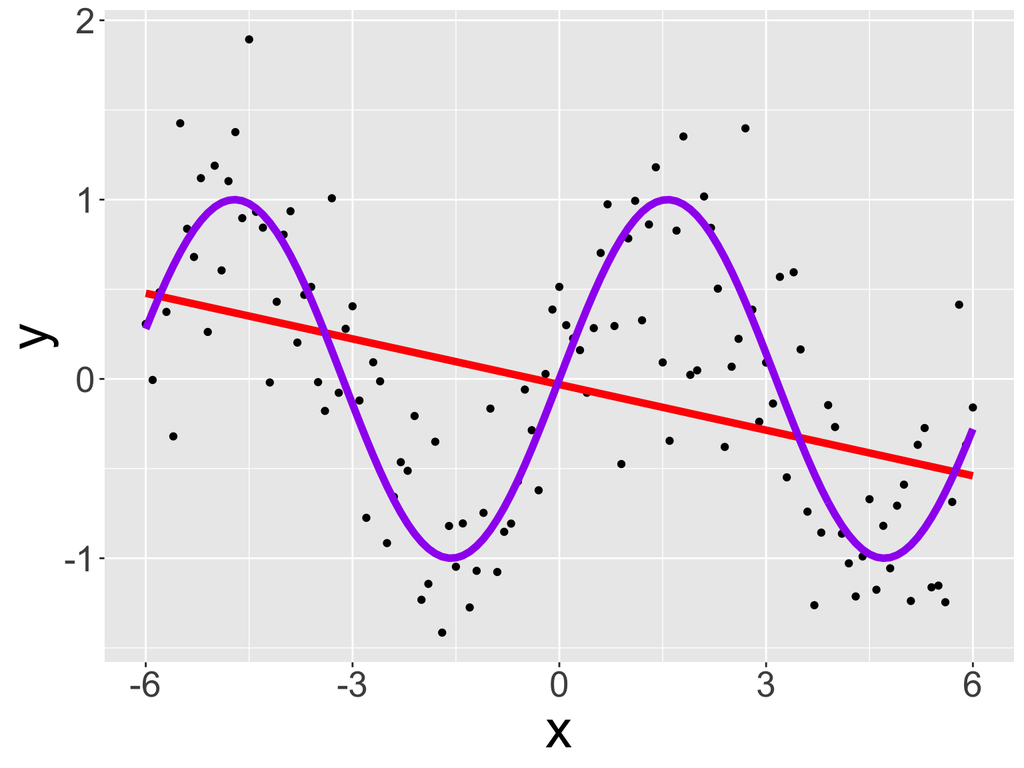

  | x | y | y_true |
  | --- | --- | --- |
  | -6.0 | 0.306450529 | 0.27941550 |
  | -5.9 | -0.005761892 | 0.37387666 |
  | -5.8 | 0.483365883 | 0.46460218 |
  | -5.7 | 0.373730825 | 0.55068554 |
  | -5.6 | -0.320387037 | 0.63126664 |
  | -5.5 | 1.425693307 | 0.70554033 |
  | -5.4 | 0.837394632 | 0.77276449 |
  | -5.3 | 0.680184558 | 0.83226744 |
  | -5.2 | 1.119579350 | 0.88345466 |
  | -5.1 | 0.262042912 | 0.92581468 |

  [output cut: 111 more lines]

# KNN

- Main Idea of KNN: given a new observation $x_0$, find the $K$ **nearest** observations among $\{x_i, i = 1,\cdots,n\}$.
- What is near? Measure by the Euclidean Distance $\|x_i - x_0\|_2^2 = (x_i - x_0)^2$.
- Let’s say the smallest are $x_{i_1},\cdots,x_{i_K}$. Then, we have
  $$\hat y_0 = \frac{1}{K}\sum_{j=1}^K y_{i_j}.$$

# Different choice of $K$

| k | train_error | test_error |
| --- | --- | --- |
| 1 | 0.00000 | 581.8208 |
| 10 | 22.81288 | 364.5425 |
| 121 | 68.58850 | 964.9834 |

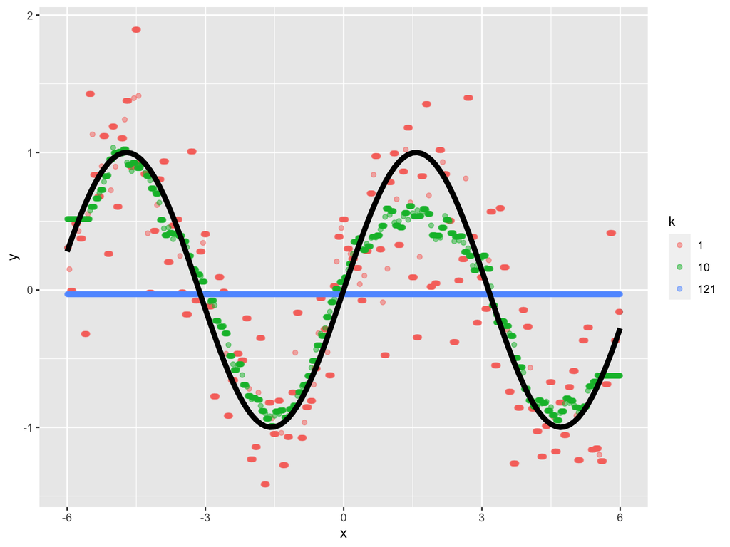

- $K=1$: perfect fit on training data, too rough, bias low, variance high
- $K=121$ (sample size): constant fit, just the sample average, too smooth, bias high, variance low (0)
- $K=10$: a good balance